# Estatística Descritiva com R

Parte 2

## Inferência Estatística

## O processo da inferência estatística

- Usando as técnicas de Estatística Descritiva, podemos fazer afirmações válidas para uma amostra.
- Já em Inferência Estatística, queremos fazer afirmações válidas para toda a população. Isto é, queremos fazer generalizações para a população a partir da amostra, conforme ilustrado na Figura abaixo.

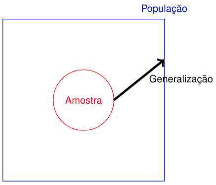

Ilustração da inferência estatística.

## O que podemos fazer com Inferência Estatística?

- **Estimação pontual:**
  - utilizar os dados observados (amostra) para encontrar o melhor palpite sobre o parâmetro (populacional). Usamos uma estimativa para ``aproximar’’ o parâmetro.
- **Exemplo:**
  - com base em uma amostra da população de Salvador com 25 anos ou mais (conjunto de dados observados), qual seria nosso melhor chute para a média salarial (em R$) dessa população?

## O que podemos fazer com Inferência Estatística?

- **Intervalo de confiança:**
  - utilizar os dados observados (amostra) para encontrar um intervalo numérico \((a,b)\), tal que o parâmetro populacional de interesse esteja contido nesse intervalo com algum *nível de confiança* pré-fixado.
- **Exemplo:**
  - com base em uma amostra da população de Salvador com 25 anos ou mais (conjunto de dados observados), qual seria o intervalo numérico que contém o valor da média salarial (em R$) dessa população *95% de confiança*?

## O que podemos fazer com Inferência Estatística?

- **Teste de hipóteses:**
  - decidir entre duas hipóteses científicas \(H_0\) e \(H_1\), onde \(H_1\) é negação de \(H_0\).
- **Exemplo:**
  - queremos decidir entre: \[ \begin{cases} H_0: \mbox{a média salarial é menor ou igual a R\$ 1000,00}\\ H_1: \mbox{a média salarial é maior do que R\$ 1000,00}\\ \end{cases} \]

## Intervalos de confiança

### Intervalo de confiança para a média populaional

- Usamos quando a variável de interesse é quantitativa.
- Seja \(\mu\) a média na população. Queremos encontrar \(a\) e \(b\) tal que \(a < \mu < b\) com coeficiente de confiança \(\gamma\).

### Intervalo de confiança para a proporção populacional

- Usamos quando a variável de interesse assume uma de duas opções (`sucesso` e `fracasso`).
- Seja \(p\) aproporção de sucesso na população. Queremos encontrar \(a\) e \(b\) tal que \(a < p < b\) com coeficiente de confiança \(\gamma\).

## Intervalo de confiança para a média populacional

Considere a variável `salario` do conjunto de dados `empresa.xlsx`.

Suponha que desejamos construir um intervalo de confiança para a média salarial com coeficiente de confiança \(\gamma = 98\%\).

```r
dados <- read_xlsx("../data/raw/empresa.xlsx")
ci_general(dados$salario, conf_level = 0.98)
```

```
## # A tibble: 1 × 3
##   lower_ci upper_ci conf_level
##      <dbl>    <dbl>      <dbl>
## 1     9.26     13.0       0.98
```

## Interpretação do intervalo de confiança

Para cada amostra (ou estudo), o intervalo de confiança pode estar correto (\(a < \mu < b\)) ou pode estar incorreto (\(\mu < a\) ou \(b < \mu\)).

No conjunto de dados `amostras.xlsx`, temos seis amostras de uma população com média \(25\), e vamos calcular o intervalo de confiança para cada amostra.

```r
dados <- read_xlsx("../data/raw/amostras.xlsx")
intervalos <- dados |>
  group_by(amostra) |>
  summarise(li = ci_general(valores)$lower_ci, ls = ci_general(valores)$upper_ci)
gt(intervalos) |>
  fmt_number(
    columns = c(li, ls),
    decimals = 2,
    dec_mark = ",",
    sep_mark = "."
  ) |>
  cols_label(
    amostra = md("**amostras**"),
    li = md("**Limite inferior**"),
    ls = md("**Limite superior**")
  )
```

| **amostras** | **Limite inferior** | **Limite superior** |
| --- | --- | --- |
| amostra_1 | 24,33 | 26,00 |
| amostra_2 | 24,24 | 26,01 |
| amostra_3 | 24,33 | 25,75 |
| amostra_4 | 23,02 | 24,51 |
| amostra_5 | 25,13 | 25,94 |
| amostra_6 | 24,16 | 24,89 |

## Interpretação do intervalo de confiança

**Importante:** \(\gamma\%\) dos intervalos de confiança estão corretos e contêm o verdadeiro valor (desconhecido) do parâmetro populacional.

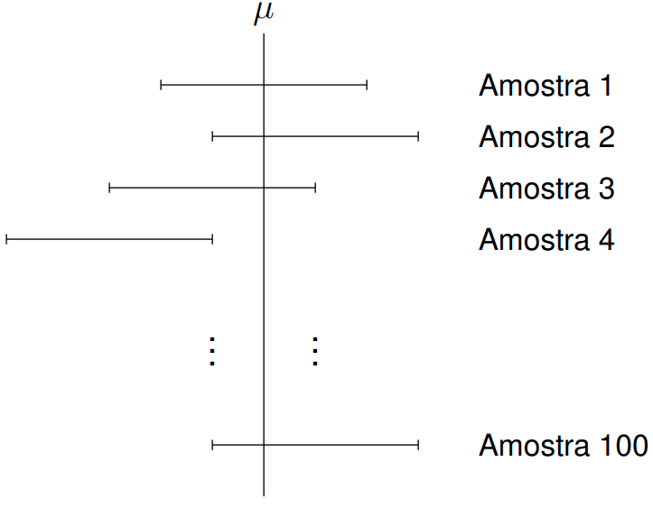

Interpretação do intervalo de confiança: 𝛾% dos intervalos estão corretos.

## Intervalo de confiança para a proporção populacional

Considere a variável `procedencia` do conjunto de dados `empresa.xlsx`.

Suponha que desejamos construir um intervalo de confiança para a proporção de pessoas que vieram da capital com coeficiente de confiança \(\gamma = 99\%\).

Nesse caso, temos

- `sucesso`: funcionário nasceu na capital;
- `fracasso`: funcionário não nasceu na capital.

```r
dados <- read_xlsx("../data/raw/empresa.xlsx")
ci_bern(dados$procedencia == 'capital', conf_level = 0.99)
```

```
## # A tibble: 1 × 3
##   lower_ci upper_ci conf_level
##      <dbl>    <dbl>      <dbl>
## 1   0.0909    0.520       0.99
```

## Teste de hipóteses

**Objetivo:** decidir entre duas hipóteses científicas \(H_0\) e \(H_1\), onde \(H_0\) é chamada de hipótese nula e \(H_1\) é chamada de hipótese alternativa.

### Como estabelecer \(H_0\) e \(H_1\)

- Valor padrão (*benchmark* do mercado ou *benchmark* do regulador) ou especificação do cliente vai sempre no \(H_0\).
- Hipótese científica ou pergunta vai sempre no \(H_1\).

Ao decidirmos, podemos errar de duas formas:

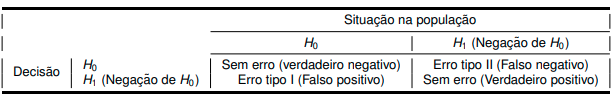

Tipos de erros que um analista pode cometer ao decidir usando as informações (*evidências estatísticas*) de uma amostra.

## Teste de hipóteses

Impossível estabelecer uma decisão que miniza, simultaneamente, \(\alpha\) e \(\beta\) (ou minimiza \(\alpha\) e maximiza \(1-\beta\)).

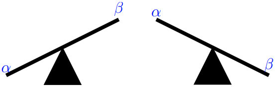

Ilustração dos erros tipos I e II. Impossível minimizar, simultaneamente, 𝛼 e 𝛽.

## Teste de hipóteses

**Falso positivo:** é o erro mais grave!

### Estratégia para especificar \(H_0\) e \(H_1\):

1. Determinar o erro mais grave que será o falso positivo;
2. Determino \(H_0\) e \(H_1\) a partir do falso positivo.

##### Exemplo (Ilustração do falso positivo)

Em um julgamento precisamos decidir se um *réu* é: **inocente** ou **culpado**.

Temos dois erros possíveis:

- Culpar um inocente;
- Inocentar um culpado.

Determinando as hipóteses nulas e alternativas:

1. O erro mais grave é **culpar um inocente**;
2. **Falso positivo** é culpar um inocente;
3. \(\begin{cases}H_0: \mbox{o réu é inocente}\\ H_1: \mbox{o réu é culpado}\end{cases}\).

## Valor-p

### Descrição intuitiva

- `estatística teste`: quantidade que indica a *evidência* contra \(H_0\). Quanto mais *extrema* (muito pequeno ou muito grande), mais *evidência* temos contra \(H_0\).
- O valor-p, ou *p-value* em inglês, é a probabilidade de coletar uma outra amostra com **estatística teste** igual ou mais extrema do que a amostra observada coletada quando \(H_0\) é verdadeira. Lembre que o erro tipo I ou falso positivo é o mais grave.
- Rejeitamos \(H_0\) quando o valor-p é pequeno, e usamos como valor de referência o nível de significância \(\alpha\%\). Ilustramos essa ideia na Figura abaixo.

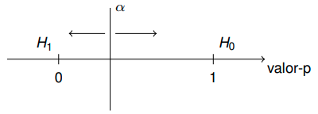

Decisão usando o valor-p.

## Valor-p

### Interpretação

Imagine um contexto em que \(H_0\) é verdade. Neste contexto, o valor-p pode ser pequeno ou grande, ou seja, podemos rejeitar ou não a hipótese nula.

O importante é que para \(\alpha \cdot 100 \%\) das amostras rejeitaremos \(H_0\).

```r
dados <- read_xlsx("../data/raw/amostras.xlsx")
dados |>
  group_by(amostra) |>
  summarise(valor_p = t.test(valores, mu = 25)$p.value) |>
  gt() |>
  fmt_number(
    columns = valor_p,
    decimals = 2,
    sep_mark = ".",
    dec_mark = ","
  ) |>
  cols_label(
    amostra = md("**Amostras**"),
    valor_p = md("**Valor-p**")
  )
```

| **Amostras** | **Valor-p** |
| --- | --- |
| amostra_1 | 0,68 |
| amostra_2 | 0,77 |
| amostra_3 | 0,91 |
| amostra_4 | 0,00 |
| amostra_5 | 0,01 |
| amostra_6 | 0,01 |

## Teste de hipóteses para a média populacional

A média salarial dos funcionários é maior que 5 salários mínimos ao nível de significância de \(5\%\)?

\[ \begin{cases} H_0: \mbox{a média salarial é no máximo 5 salários mínimos},\\ H_1: \mbox{a média salarial é mario que 5 salários mínimos}. \end{cases} \]

```r
dados <- read_xlsx("../data/raw/empresa.xlsx")
t.test(dados$salario, mu = 5, alternative = "greater")
```

```
##
##  One Sample t-test
##
## data:  dados$salario
## t = 8.0073, df = 35, p-value = 1.006e-09
## alternative hypothesis: true mean is greater than 5
## 95 percent confidence interval:
##  9.830415      Inf
## sample estimates:
## mean of x
##  11.12222
```

## Teste de hipóteses para a proporção populacional

Os funcionários com origem na capital são maioria ao nível de significância \(1\%\)?

\[ \begin{cases} H_0: \mbox{a porcentagem de funcionários com origem na capital é no máximo 50%},\\ H_1: \mbox{a porcentagem de funcionários com origem na capital é maior que 50%}. \end{cases} \]

```r
dados <- read_xlsx("../data/raw/empresa.xlsx")
num_sucessos <- sum(sum(dados$procedencia == 'capital'))
tamanho_amostra <- nrow(dados)
prop.test(num_sucessos, tamanho_amostra, p = 0.5, alternative = "greater")
```

```
##
##  1-sample proportions test with continuity correction
##
## data:  num_sucessos out of tamanho_amostra, null probability 0.5
## X-squared = 4.6944, df = 1, p-value = 0.9849
## alternative hypothesis: true p is greater than 0.5
## 95 percent confidence interval:
##  0.1851783 1.0000000
## sample estimates:
##         p
## 0.3055556
```

## Associação entre duas variáveis quantitativas

Para duas variáveis quantitativas, estudamos a associação entre as duas variáveis usando o gráfico de dispersão. Além disso, podemos calcular o coeficiente de correlação linear de Pearson.

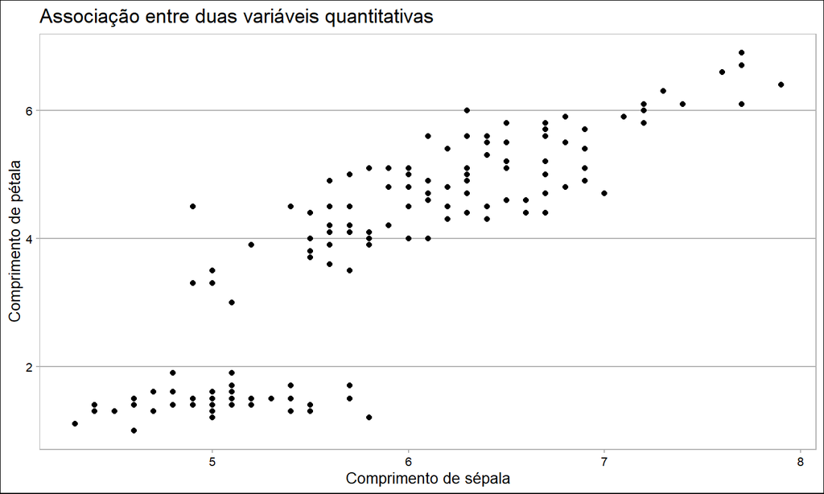

```r
df_iris <- read_xlsx("../data/raw/iris.xlsx")

ggplot(data = df_iris) +
  geom_point(aes(x = Sepal.Length, y = Petal.Length)) +
  labs(x = "Comprimento de sépala", y = "Comprimento de pétala",
       title = "Associação entre duas variáveis quantitativas") +
  theme_calc()
```

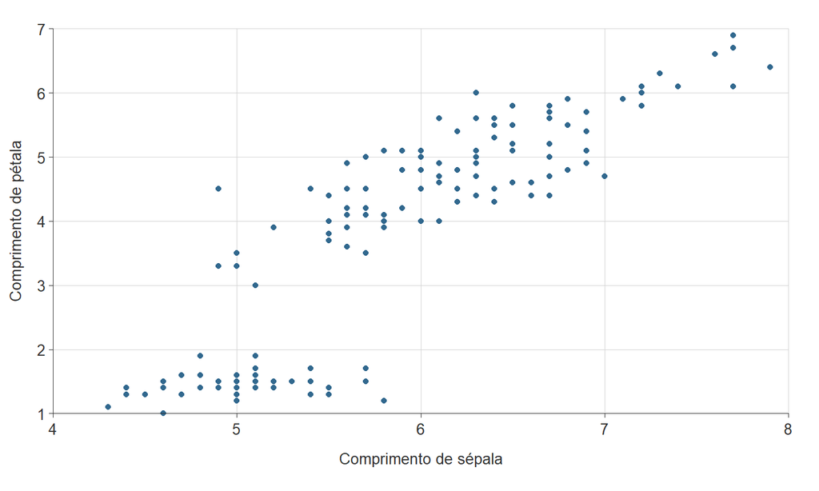

```r
library(simplevis)

df_iris <- read_xlsx("../data/raw/iris.xlsx")

gg_point(df_iris,
       x_var = Sepal.Length, y_var = Petal.Length,
       x_title = "Comprimento de sépala", y_title = "Comprimento de pétala")
```

## Associação entre duas variáveis quantitativas

Também podemos calcular o coeficiente de correlação linear de Pearson. Lembre que se \(X\) e \(Y\) são duas variáveis quantitativas com valores

Amostra de duas variáveis quantitativas \(X\) e \(Y\).

| \(X\) | \(x_1\) | \(x_2\) | \(\cdots\) | \(x_n\) |
| --- | --- | --- | --- | --- |
| \(Y\) | \(y_1\) | \(y_1\) | \(\cdots\) | \(y_n\) |

Então, o coeficiente de correlação linear é dado por \[ \begin{split} r &= \left( \dfrac{(x_1-\overline{x})}{s_x} \cdot \dfrac{(y_1 - \overline{y})}{s_y} \right) + \cdots + \left( \dfrac{(x_n-\overline{x})}{s_x} \cdot \dfrac{(y_n - \overline{y})}{s_y} \right). \end{split} \]

```r
cor(df_iris$Sepal.Length, df_iris$Petal.Length)
```

```
## [1] 0.8717538
```